# Animations in ggplot - gganimate

Gareth Green

# Animated visuals

- How many of you have seen this famous [gapminder video of Hans Rosling](https://www.bing.com/videos/search?q=hans+rosling&view=detail&mid=4CC1172C798C8C3BD2A94CC1172C798C8C3BD2A9&FORM=VIRE)
- Animated visuals can help tell a story
  - especially in a presenation
  - you can tell the story while the visual progresses
- Animations are especially good for time series
  - can work well for other forms of motion as well
    - for example, how median price changes with number of bedrooms
  - key is that members of a group differ over the varialbe that you are animating over
- Only use if the animation ads substance
  - do not just use animations to show sizzle
- You can save these in your TA and call them later
  - `anim_save()` is much like `ggsave()`

# Animated visual basics

- I want to show you a similar animation to the one Hans used
- We will be using gganimate
  - I will show several examples of how to use gganminate
  - there are several differnt functions and they continue to develop new ones
- Here we use the function `transition_time()`
  - this has the visual transition along a variable that is not in the plot
  - see that `year` is not in `ggplot()` but it is in `transition_time(year)`

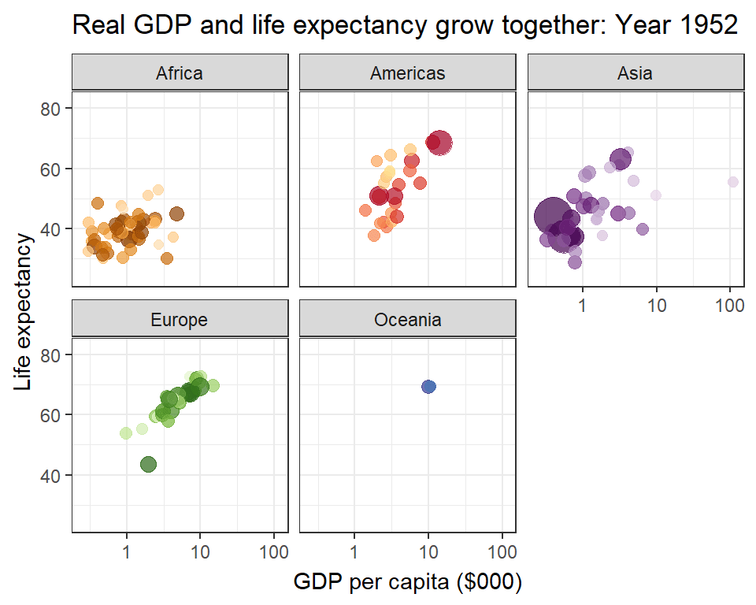

```r
# Load package with gapminder data
library(gapminder)

# Build a faceted animation graph
ggplot(data = gapminder,
       mapping = aes(x = gdpPercap/1000, y = lifeExp,
                     size = pop, color = country)) +
  geom_point(alpha = 0.7, show.legend = FALSE) +
  scale_colour_manual(values = country_colors) +
  scale_size(range = c(2, 12)) +
  scale_x_log10() +
  facet_wrap(~continent) +
  theme_bw() +

  # Here comes the gganimate specific bits
  labs(title = "Real GDP and life expectancy grow together: Year {frame_time}",
       x = "GDP per capita ($000)", y = "Life expectancy") +
  transition_time(year) +
  ease_aes("linear")
```

# Time-series animation visuals

- Here is a typical time series visual
  - here I use `transition_reveal()` by the x-variable in `ggplot()`
  - also set `frame = yr_built` for the visual to transition along
- I use `annimate()` to set the speed of the reveal

[figure not shown]

```r
# Graph median price by year built
p <- qp1 %>%
  select(yr_built, waterfront, price) %>%
  group_by(yr_built, waterfront) %>%
  summarize(med_price = median(price/1000)) %>%
  ggplot(aes(x = yr_built, y = med_price, frame = yr_built)) +
    geom_line(aes(color = as.factor(waterfront))) +
    scale_color_manual(name = "Waterfront", labels = c("No", "Yes"), values = c("navy", "blue"),
                       guide = guide_legend(reverse=TRUE)) +
    theme_classic() +
    theme(axis.title.x = element_blank(),
          legend.position="bottom") +
  labs(title = "Waterfront median price is much more variable than non-waterfront",
       x = "", y = "Median price ($000)") +
  transition_reveal(yr_built)

# Run as a GIF annimation and control speed
animate(p, nframes = 300)
```

# Animating distinct stages of a visual

- Can also animate visuals that have discrete states
  - good for bar graphs or similar
- the variable in `transition_state()` does not have to be called in `ggplot()`
  - i.e. could have done by `view`

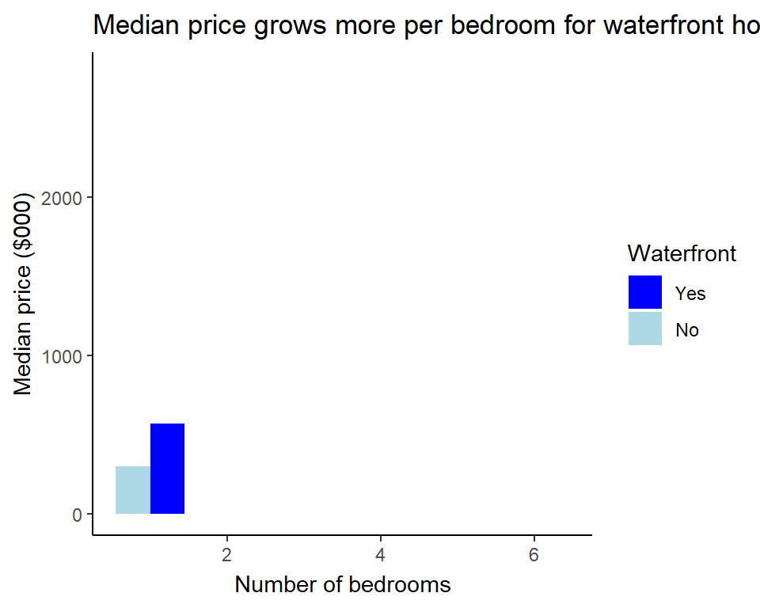

```r
# Animate a bar graph
qp1 %>%
  select(price, bedrooms, waterfront) %>%
  group_by(bedrooms, waterfront) %>%
  filter(bedrooms < 7 & bedrooms > 0) %>%
  summarise(med_price = median(price/1000)) %>%
  ggplot(aes(x = bedrooms, y = med_price, fill = as.factor(waterfront))) +
  geom_bar(stat = "identity", position = "dodge") +
  theme_classic() +
  scale_fill_manual(name = "Waterfront", labels = c("No", "Yes"), values = c("lightblue", "blue"),
                    guide = guide_legend(reverse=TRUE)) +
  labs(title = "Median price grows more per bedroom for waterfront homes",
       x = "Number of bedrooms", y = "Median price ($000)") +
  transition_states(bedrooms, wrap = FALSE) +
  shadow_mark()
```